Center for Health Data Science, November 2023

# Exercises

This markdown document contains the exercises for the introductory workshop on command line use, entitled `Just Bash It`.

## Getting started

If you have not done so yet, download the materials from the github repo https://github.com/Center-for-Health-Data-Science/Just-Bash-It by selecting the green `Code` button on the top right and then `Download ZIP`. We suggest that you put it into your Documents folder so you can easily navigate to it with the terminal.

You also need to unzip the folder. On most systems this should be possible with right clicking on the folder and selecting `Extract` or something similar.

### Windows

You should have installed git bash as detailed in the prep email. Open the terminal by writing ‘git bash’ into the windows search console and select the app.

You should see something like this:

[figure not shown]

Go to where you have placed the unzipped git repo. If it is on your Documents you would do:

```bash
cd Documents
cd Just-Bash-It
```

You should see something like this:

[figure not shown]

Today we will work inside the workshop repo for the exercises and code-along. But you are of course free to explore the rest of your hard drive!

### Mac

Open the terminal with the launch pad (Cmd + space, then type terminal).

Then navigate to where you have placed the unzipped git repo. If it is on your Documents you would do:

```bash
cd Documents
cd Just-Bash-It
```

It should look similar to the screenshot above in the Windows section, except that your terminal is probably white.

Today we will work inside the workshop repo for the exercises and code-along. But you are of course free to explore the rest of your hard drive!

### Linux based systems

Open the terminal either via the launch pad or by holding Ctrl+Alt+t.

Then navigate to where you have placed the unzipped git repo. If it is on your Documents you would do:

```bash
cd Documents
cd Just-Bash-It
```

It should look similar to the screenshot above in the Windows section.

Today we will work inside the workshop repo for the exercises and code-along. But you are of course free to explore the rest of your hard drive!

## A note on pseudo code

Some exercises and explanations in this document contain what is called ‘pseudo code’. Pseudo code is an abstracted way to write an idea of code. It will not necessarily run when executed, so **do not copy** pseudo code straight into the command line. Rather it explains the idea of how your code should be structured. We will explicitly let you know when a snippet is *pseudo code*.

Pseudo code can look like this:

```bash
wc [your file]
```

In the above example square bracets mean you need to **replace** what is between them with the actual file, expression, ect you want to use. The square bracets themselves are not part of the code. For example, if you wanted to word count the readme file, you would replace `[your file]` with `README.md`:

```bash
wc README.md
```

## Getting help

There are different ways of getting help:

- On Mac and Linux based systems, you can use `man [name_of_command]` to see a manual of the command. Not all commands have a manual.
- On git bash (Windows), but also Mac and Linux, you can use `[name_of_command] --help` or `[name_of_command] -h` if the long option is not recognized. Not all commands have a help function.
- Googling the command or the error usually brings up good results
- You can also ask us during the exercise session, we are here to help you :).

There will be many error messages because things always go wrong and nobody knows or remembers how to do everything (including us!). It is very important that you apply step 1 of the error resolution procedure: **Don’t Panic** (we might need a citation here :P). The computer will generally tell you if you’re doing something it doesn’t understand or that is wrong.

## Exercise 1: Navigating Files and Directories

1. List the contents of the top directory of the workshop, `Just-Bash-It`. You should see something like this:

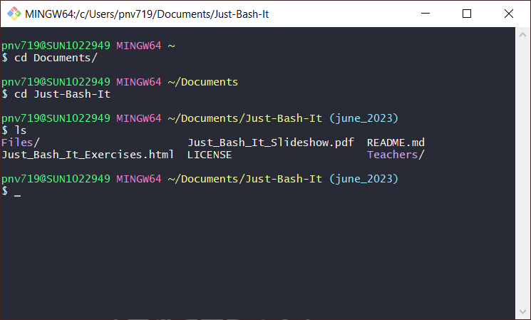

- How many objects (files and directories) are there in the directory?
- Which ones are files and which are (sub) directories? How can you tell?
2. Now, add the flag `-l` (that’s the small letter L) to the `ls` command. What changes?

   ```bash
   ls -l
   ```

   Search the web to get an explanation of the output. What do the individual fields show?  
   Use the help of ls `ls --help` (git bash) or `man ls` (on mac/linux) as well as what you learned in the lecture to answer the following questions:
- Which listed items are files and which are directories?
- Which file in `Just-Bash-It` is the largest?
- Are there any hidden files (that you normally don’t see with a simple `ls`)?

  If you cannot see the relevant infos like size, use the `-l` option in combination with other options found in the help (or by googling).

For the rest of this exercise we are going to work in the `Files` folder.

3. Change directory to the `Files` folder and list its contents.
4. Now list the contents of the `Documents` folder without going into it.
5. Change directory into the `Documents` folder (inside the `Just-Bash-It` folder) and check what your current working directory is.
6. Change directory to the `Courses` folder. Are there any files inside?
7. What is the full path of the file inside the `Courses` folder? You can test your answer with

   ```bash
   ls [path]
   ```

8. From here, go to the `Pictures` folder (Hint: This folder should have been listed under point 3). Can you do it using the `../` syntax?
9. What is your current working directory?
10. What is the relative path to the text file in the `Courses` folder from where you are right now? You can check your answer by using `ls [relative path to file]` and seeing whether it shows the file.

## Exercise 3: Project organization

Let’s get structured!

1. Make a `projects` directory where you would like it on your computer, for example on the Desktop or in your Documents.  
   Inside the `projects` directory, create a directory for this course. You could name it i.e. **Just_Bash_It, Intro_to_command_line, First_Project, etc.**. Then inside that directory, create all the sub-directories shown on **slide 43** in the slideshow.
2. Using the command-line, navigate back to where you have the course repo `Just-Bash-it`. Inside the `Files` directory there is a `Data` directory with the files we are going to use for the rest of the course. Move the compressed files (those with extension `.gz`) to the project directory you have made in **point 1** and place them in the correct sub-directory.
3. How large (in bytes and disk space) are the data files you moved from the course materials?
4. Check the permissions of the data files. Do you have permission to `read`, `write` and `execute` them? If you do not have permission to execute the files, what is the reason for this?
5. Make a new file called `Readme.txt` inside the directory you made under point 1.

## Exercise 4: Viewing and editing files

1. Go to your project directory and edit the `Readme.txt` file you made in **Exercise 3** using the one of the editors `nano`, `vim or vi`, `emacs`. **N.B** you might only have one of them installed!  
   A `readme` file should contain information about what a certain directory contains, its purpose and who owns it/is the editor.
2. Move to the sub-directory `Data/Raw` here you should have the four data files you moved from the course material directory.

   Two of these files are `fastq` files, they contain RNAseq reads from a bulk-RNA sequencing experiment using Arabidopsis thaliana (thale cress). The extension `_R1` and `_R2` denote that reads are paired-end (e.g. read 1 and read 2). The other two are `gff` files that contain gene annotations and other genomic features. We will first work with the file `GCF_genomicAnnotation.gff.gz` which contains info on the model organism Arabidopsis Thaliana.
3. Uncompress the `GCF_genomicAnnotation.gff.gz` annotation file while making sure you keep a copy of the compressed version.  
   **HINT:** look into what flags/arguments need to be specified when decompressing).
4. Try out the commands `less, cat, head, tail` on the expanded `.gff` file and study its content.

   You will notice that the file is made of two parts: A header part that contains information about the file and a data part that contains data in columns separated by whitespace. Lines that are part of the header start with a hash tag. The hash tag is generally the comment character, indicating that a line is not data.

   The data section of the file contains the fields (columns) shown below, and includes information on: annotation source, region, sequence start and end position, stand, as well as a column containing various information on the sequences, i.e. entry id, gene name, locus, ids, tags etc.

   | NC ID | Source | Region | Start | End | Strand | Gene transcript etc. |
   | --- | --- | --- | --- | --- | --- | --- |
   | NC_003070.9 | RefSeq | exon | 4706 | 5095 | + | gene=ARV1;locus_tag |

5. Run the `head` command again on `GCF_genomicAnnotation.gff` and save the result into a new file called `gcf_head.txt`.
6. Rename the expanded `.gff` to `Annotation.gff`. Move the `Annotation.gff` and `gcf_head.txt` to your `Scratch` directory.
7. **Without uncompressing the entire file**, have a look at the content of one of the two `fastq.gz` files that contain RNA sequencing reads.

## Exercise 5: Data Wrangling 1

You will now test out some of the new commands introduced in the slide show and the command line presentation.

1. Figure out how many, lines, words and characters the `Annotation.gff` file contains using `wc`.
2. In Exercise 4 we established that the file is composed of a header part and a data part. We would like to remove the header, denoted by hash tags, for further processing and save the resulting file into a new file called `Annotation_tmp.gff` (so we still have `Annotation.gff` containing the header and the new file without it).

   We can do this in many ways but here we will chose to use the stream editor `sed` and omit the header lines by their line number.

   Have a look at the *pseudo code* below:

   ```bash
   sed '[number first line],[number last line]d' Annotation.gff > Annotation_tmp.gff
   ```

   You need to find the numbers and run the command. What do you think the `d` refers to?

   Have a look at the resulting `Annotation_tmp.gff` and verify whether it is correct. That means it should not contain any of the lines starting with a hash tag but all the other lines in `Annotation.gff`. If it is not correct try again until you have the correct file.
3. For further analysis, we want to cut out only the columns that have the information on the *Region*, *Start* and *End* of the genetic element. You will do this by using `cut` on `Annotation_tmp.gff` and redirecting the output into a new file called `GenomicRegion.tmp`.  
   **HINT1:** First, identify the position (1,2,3,ect) of the columns we want.  
   **HINT2:** A challenge you might encounter is that the annotation file is separated by the *tab* delimiter, which in unix is written as: `\t`. For some systems, `cut` without a specified delimiter will work fine. *If* we need to specify the delimiter as `\t` (instead of say space) we need to put a `$` in front of it like so: `-d$'\t'` (there are no spaces here!). Don’t ask, it’s a long story… Check that your output file looks correct.

Next, we would like to extract the gene names. They are in field/column 7 in the `Annotation_tmp.gff`, but field 7 contains itself several entries like ID, gene name, locus tags etc. separated by a `;`. I.e. field 7 contains sub-fields delimited by `;`.

4. Extract the gene name by using `cut` twice. First, cut out column 7 from `Annotation_tmp.gff` and name that temporary file `col7.tmp`. Inspect `col7.tmp` for example with `head` and count which of the subfields you want to extract. We want the sub-field starting with `gene=`. Some lines in the gff file do not have the `gene=` field because they are other genomic features. But since this is just an exercise, we will be content with cutting based on the field’s position. When you have found it, cut `col7.tmp` and put the result into `gene_names.txt`.

Check that your output file looks correct. It should look like this:

[figure not shown]

5. We would now like to remove the `gene=` in each line to just obtain the clean **gene name** by itself. One way to get this is to do a search and replace with `sed`.

   The syntax is shown as *pseudo code* below. The `sed` command requires you to specify what pattern to match `[pattern to match]` and what pattern to replace it with `[Replace with]`. The patterns are separated by slashes and the whole expression is encased in quotes `'`.

   **Note:** When using `sed` the input and output file cannot be the same, i.e. you cannot overwrite the input file in one command. But you could of course rename the output file to be the input file later with `mv`.

   ```bash
   sed 's/[pattern to match]/[Replace with]/g' [input file] > [output file]
   ```

   For the pseudo code chunk figure out:
- What the input file should be?
- Change `[pattern to match]` to the pattern you want to match and `[Replace with]` to what you want to replace with (*HINT: replace with empty/nothing*).
- What does the `s` and `g` denote?
- Run the command and save the output to the a file and call it `gene_names_clean.txt`: .

  Verify that your output looks correct, i.e. the `gene=` part is gone but the gene names are still complete. It should look like this:

[figure not shown]

## Exercise 6: Data Wrangling 2

You should now have one file `GenomicRegion.tmp` containing only field 3, 4 & 5 from exercise 5.3 and one `gene_names_clean.txt` containing gene names from exercise 5.5.

1. Paste these two files together into a single file using the command `paste`. Name this file `Annotation_Gene.gff`. The new file should be tab separated, just like the `GenomicRegion.tmp` file. To do so, use the delimiter flag to specify what kind of delimiter should be used to paste the fields together (tab is `\t`).
2. Run and decipher the command below.

   ```bash
   awk -F '\t' 'OFS="\t" {$5=$3-$2}{print}' Annotation_Gene.gff > Annotation_Gene_Len.gff
   ```

- What is the output of the command?
- What does the flag `-F` specify?
- What does `OFS="\t"` mean? *HINT: Google this!*
- What is going on inside the curly brackets?
3. Let’s have a look at the content of your final file:
- Are there any gene sequences with length 0 in the annotation file? - Try the command `sort` with flags `-k 5`, `-n` and `-t$'\t'` . Like `cut` `sort` needs some help with multi-field delimiters.
- What is the name of the gene with the longest sequence, annotated in your file? - Try the command `sort` with flags `-k 5 -nr`.
- Does our organism of study, Arabidopsis Thaliana, have the `TERT` gene? - Try the command `grep`.
- All living organisms have polymerase genes (`POL` genes), check that Arabidopsis Thaliana also has one.
- How many gene annotation lines in the file pertain to transfer RNA (`tRNA`)? Use `grep` and find the correct flag for counting.

Your new file `Annotation_Gene_Len.gff` does not have a header line explaining what the different columns are.

4. Using an editor, i.e nano, make a new file called `header.gff` with these column names:

   ```bash
   Region    Start   End   GeneName    Length
   ```

   The column headers should be separated by tab, just like the data columns.

Now, use the command `cat` to put `header.gff` and `Annotation_Gene_Len.gff` together. Name the output `Annotation_[TodaysDate].gff`.

When you have checked at the file looks correct, move the file to your **Results** directory - **N.B** go to the sub-directory and check that you have moved it correctly!. You can now remove (delete) all the temporary files in your `Scratch` directory. WELL DONE!

## Exercise 7: Redirection & Pipes

1. Copy (`cp`) the unzipped gff file for Arabidopsis Thaliana from your `Data/Raw` dir to the `Scratch` dir. It might be called `GCF_genomicAnnotation.gff` or `Annotation.gff` if you have renamed it in exercise 4. Then move to the `Scratch` directory.

   Lets try some piping (chaining) of commands.
2. Starting from the unzipped gff file we just copied,find out which types of genomic features (i.e. exon, rRNA, repeat) we have information on by chaining 4 commands together with the pipe operator `|`.

   When using a pipe, the output from the first command becomes the input to the second command. This enables us to do operations with less intermediate files.

   **Tip:** When testing chained commands you can be unsure what the outputs and inputs are at each pipe, or if a command has produced the expected output that you want to pass on. It is therefore a good idea to build the command step by step. You can execute step 1, check the output, then add step 2 and so forth until you have assembled your command. If you get tired of having the output fill up your screen you can always chain a `head` (i.e. `cut -f [colunm] [file] | head`) after the step to only see the first 10 lines of output.

   You have probably tried many commands in the last exercises and it can be difficult to remember what has worked or how exactly the syntax was. Luckily, all commands you have typed into your terminal are saved in the `history`!

   First, let’s see how much is in your history. What does the below command tell you?

   ```bash
   history | wc
   ```

   If you have a lot of commands saved in your history you might only want to see the last 20 or so. Can you show the last 20 commands using a pipe?
6. Finally, let’s **redo points 2-5 from Exercise 5 and point 1 from Exercise 6**, starting from the `Annotation.gff` file, BUT this time using pipes to reduce the number of intermediate files. You should end up with a file containing these 4 columns: `Region, Start, End and gene name (only)`. Use your `history` if you can’t remember the commands you used.

   There are many ways of achieving this. For those who like a challenge, it is possible to get to the final output file in two command lines (i.e. only one intermediate file) by using `-` to read input from stdin (instead of specifying the name of the input file).  
   **HINT:** The commands do not need to be combined in the same order as in Exercise 5, in fact, they should not.

## Exercise 8: Part 1: Shell Scripts

We will now save the commands from exercise 7.6 in a script so we don’t lose them and can easily re-run our analysis with a different gff file.

2. Create a new file, either directly on the commandline with `touch` or with the editor of your choice, and name it `ex8.sh`. This is the file which will contain your script.
3. Using your `history`, find the commands you used to solve exercise 7.6 and copy them into the file `ex8.sh`. Save the script. If you use `echo` for this, view the script file to verify that it looks as expected.
4. Run `ex8.sh` by calling `bash`. Does it run without error? If not, correct what is wrong until it does. Check that it creates the correct files, i.e. they should look the same as when you manually executed the commands.

   ```bash
   bash -x ex8.sh
   ```

5. Add lines to your script `ex8.sh` that will remove the temporary files created. Check that these files are indeed removed, and no other files have been deleted by accident. If you did end up deleting something you still need can just re-download the respective file from github.
6. Now replace the name of the input file, `GCF_genomicAnnotation.gff.gz`, with an argument so that you can run your script on different input files. In order to make this work we need to start from a **zipped file**, so we can apply this script to other gff files without having to manually unzip them first. So the first task is to find out how to unzip a gz file and redirect the output into a new file, so we will both leave the original file (i.e. `ecoli.gff.gz`) and control the name of the unzipped file. We do not want the unzipped file to be named `ecoli.gff` because then our script will only work on that particular file! To do this, look at the help for gzip and figure out which argument you need. A hint, we are trying to write to standard out and redirect that output into a file of our choice.

   ```bash
   gunzip -h
   ```

   With this, write up a command that takes `ecoli.gff.gz` (or any other .gz file) and creates an unzipped file `unzipped.gff` while also leaving the original `ecoli.gff.gz` in place. This will be the first command in your new script script.
7. Run your script on `ecoli.gff.gz` by passing the file name as an argument. Test until it works. Remember to use `-x` to see the commands the script executes displayed. For debugging it helps to leave the temporary files so you can go back and check them, so you might want to command out the lines you added in 4.

## Exercise 9: Software Installation, Upkeep & More

1. Try out the command below, what does it show you? What does `aux` specify?  
   **HINT:** Remember you can use commands like `man` and the option `-help` to help you understand what is going on. **N.B:** For Windows users git bash will only show you the processes related to running git bash itself, not so fun, but try the command anyways.

   ```bash
   ps aux
   ```

2. Using the command `open` (OS X and Ubuntu) or `start` (gitbash) to launch a text editor (notepad, Notes, Evernote, etc.) and/or an internet browser (i.e. a Firefox, Safari, etc.) though the terminal.  
   **HINT:** Make sure you spell the application name correctly, i.e. capital letters, spaces, etc.
3. If you have a Mac or linux OS, you can now kill the application you just opened by using the command line. You will have to combine the commands `ps aux` and `grep` to get the `process id (pid)` for the application. What does the `-9` mean? On gitbash this is not possible, so just proceed to the next point.

   ```bash
   kill -9 [pid]
   ```

In the second part of the exercise we will now install and run a software thought the command line. The software is [fastqc](https://www.bioinformatics.babraham.ac.uk/projects/fastqc/). It is made for quality control of DNA/RNA sequencing data. The software produces a report with different statistics of read quality and bias checks.

The steps here are different for each operating system, and easiest for ubuntu/linux users:

**OS X (mac) Users:**  
First, Check if `homebrew` is installed:

```bash
brew --version
```

**IF `homebrew` is not** installed then install it:

```bash
/bin/bash -c "$(curl -fsSL https://raw.githubusercontent.com/Homebrew/install/HEAD/install.sh)"
```

**N.B** This may take a while.  
Check `homebrew` was installed correctly by running the `brew --version` as shown above.

Install `fastqc`

```bash
brew install fastqc
```

**Ubuntu Users:**

On Ubuntu we generally use `apt-get` to install software.

First, update apt database (you might need sudo):

```bash
apt-get update
```

Install `fastqc` (you might need sudo):

```bash
apt-get -y install fastqc
```

If you have linux distribution that doesn’t have `apt-get` either google how to install things or download the java app of fastqc (see Windows) and run it with java.

**Windows Users:**

On windows, we will use java to execute the fastqc executable (which is written in java). Check whether you have java:

```bash
java -version
```

If you do not have java, download and install it: https://www.java.com/en/download/windows_manual.jsp I have used the Windows Offline 64-bit.

Next, download fastqc from here: https://www.bioinformatics.babraham.ac.uk/projects/fastqc/ . Unzip the folder, either with the command line or by right clicking on it and put the content where you want them to be.

Now you can navigate to where the executable is and see whether you are allowed to run it. For me it looks like this:

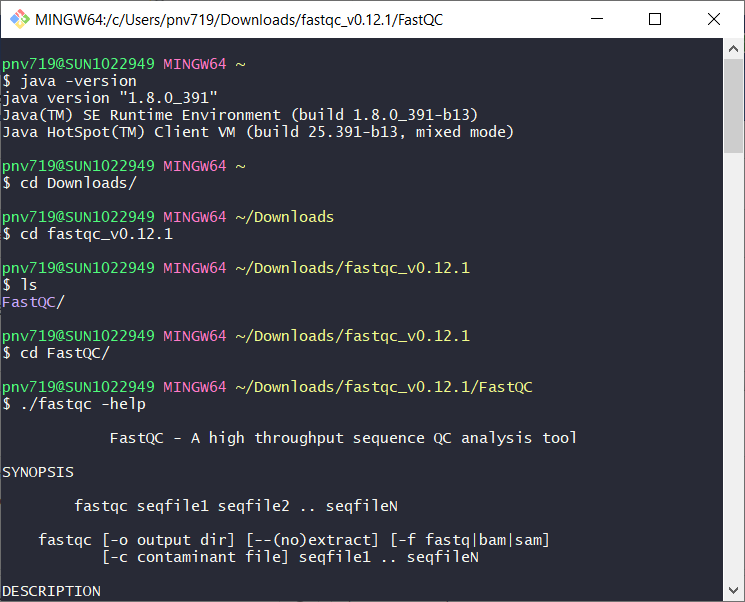

You can also run fastqc from any other directory by providing the full path to the executable (which you now have because you just checked it):

[figure not shown]

We are now ready to run `fastqc`. In the `Data/Raw` folder you have two`fastq` files, they contain RNAseq reads from a bulk-RNA sequencing experiment using Arabidopsis thaliana (thale cress). The extension `_R1` and `_R2` denote that reads are paired-end (e.g. read 1 and read 2).

3. Move the two `fastq` files to your `Scratch` folder using one command line (i.e. both files at once).
4. Go to your `Scratch` folder and run `fastqc` on the files (both at once), you will have to google how.  
   Importantly, send the output of `fastqc` (an html report) directly to the `Results` folder.  
   **HINT:** Have a look at the `fastqc --help` to figure out which flag you will need.
5. Go to your `Results` folder and open the .html report produced by `fastqc`. You can do this using the command `open or start` (depending on your system), name of your internet browser, followed by the name of the html report. See examples below.

```bash
# OS X (Mac) users:
open -a Firefox [report.html]
open -a "Google Chrome" [report.html]

# Ubuntu/Linux users:
open [report.html]

# gitbash (Windows) users:
start [report.html]
```

## Exercise 10: Computing on HPCs

For exercise 10, you will log in to our small teaching server. Emphasis on small, it only has 8 cores so some waiting time may occur for executing commands.

Part 1: Discovering the server

1. Log in to the server. You should have been given a number. This number + `stud` is the account you should use. All student account have the same password, `pass1234`. We log in with ssh:

   ```bash
   ssh stud[number]@157.180.86.52
   ```

   You may be asked whether you want to continue to this server which is not in your known hosts. Select Yes. Provide the password.

   You will know you have successfully logged in if your prompt has changed to `stud[number]@bash-teaching`.

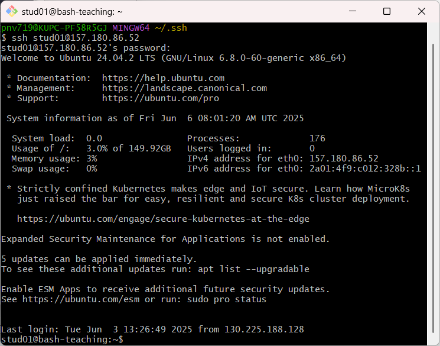

2. Take a moment to look around and locate where folders are. You have a home directory, which is the place where you landed directly after logging in. Check its path (`pwd`). Locate the project directory (`/project`) and check which directories it contains.
3. Use `module avail` to display the software available in environment modules.
4. Invoke the aligner tool bwa with:

   ```bash
   bwa
   ```

   What happens?
5. Load the bwa module `module load bwa` and invoke bwa again.
6. Confirm which modules are loaded with `module list`.
7. Unload the module with `module unload`.
8. Check the server load with `htop` (press q to quit).

Part 2: Running a small bioinformatics job

We will now submit a job to slurm. We will map reads of *Arabidopsis thaliana* to the reference genome, then sort the alignment file and get a report on mapping success with `flagstat`. We provide the script for you so there will not be an issue with the commands.

9. First, change into the project directory for *Arabidopsis thaliana* (`a_thal`). You should see a `results` directory. Inside there, create a directory with your own name. You will put your results into that directory so you don’t overwrite each others results.
10. Locate the job script in the folder `/home/boss/scripts/`. Copy the script to your OWN home folder. View it to see the different steps. Then using nano or a text editor of your choice, open the job script and change the name of the job to YOUR name so it will be easier to track. Also, everywhere it says `[YOU]` change that to the name of your folder (that you just created).
11. When you are ready submit the script to the queue with

    ```bash
    sbatch job.sh
    ```

12. Use the `squeue` command to check whether your job is running. If the state (`ST`) is `PD` the resource allocation is pending. If it is `R` the job is running and if it is `ST` the job has stopped/finished. `squeue` is not interactive, so you can check several times to to see if your status has changed after a while. Have another look at server load with `htop`. You will probably see many of the CPUs busy if jobs are running.
13. After your job has finished you will have a file named `slurm-[jobid].out` in the folder from which you started the job. You can have a look at it, it shows information from the mapping. Go to your folder in the project results and confirm whether all results were made. You should have 3 files:

    ```bash
    ls
    aln-pe.sam  flagstat.txt  sorted.bam
    ```

    If not, perhaps something has gone wrong during the executing of the job. There should be info about it in the `slurm` file.